# **FINAL PROECT - GROUP 16**

## **Malware detection by classification of malware byplot images.**

### **GROUP MEMBERS:**

*1. Praiselin Lydia Gladston*

*2. Sudharsan Tirumal*

### **PROJECT DESCRIPTION:**

The brief objective of the project is to perform multiclass classification of malware byteplot images. This means that given an image representation of a PE file, the goal is to classify it into one of multiple categories representing different types of malware.

#### Terms used:

1. **PE files:** Portable Executable files is a file format used in Windows operating system.
2. **Byteplot images:** Graphical representation of PE files created by converting the raw byte sequence of the files into pixel intensities. Each pixel in the image corresponds to a byte in the file, and its intensity represents the value of the byte.

This project is done using [this Kaggle dataset](https://www.kaggle.com/datasets/gauravpendharkar/blended-malware-image-dataset) and some code reference are taken from [this Kaggle notebook](https://www.kaggle.com/code/geogeolerigolo/malware-classification).

### **DATASET DESCRIPTION:**

The [**Malimg**](https://paperswithcode.com/sota/malware-classification-on-malimg-dataset) dataset and the [**Malevis**](https://web.cs.hacettepe.edu.tr/~selman/malevis/) dataset are two widely recognized collections used for image classification in this domain. While the Malimg dataset has imbalance in its class distribution, the Malevis dataset maintains a well-balanced distribution. To address the shortcomings of the Malimg dataset, a combined dataset is created by merging both collections. This combined dataset comprises all classes from the Malevis dataset and incorporates five classes from the Malimg dataset, resulting in a more comprehensive and diverse dataset for analysis and model development.

The advantage of merging both of these datasets are:

- Multiclass Classification of Malware Byteplot images.
- Handling RGB and Grayscale byteplot images together in one dataset.

### **IMPORTING REQUIRED LIBRARIES:**

```python
import os
import cv2
import numpy as np
from sklearn.preprocessing import LabelEncoder
from sklearn.model_selection import train_test_split
from tqdm import tqdm
import matplotlib.pyplot as plt

from tensorflow.keras.applications import ResNet50
from tensorflow.keras.models import Model
from tensorflow.keras.preprocessing.image import ImageDataGenerator

from sklearn.metrics import classification_report
from sklearn.linear_model import LogisticRegression
import lightgbm as lgb
```

### **IMPORTING TRAINING DATASET:**

Each sub-directory of the malware_dataset/train directory is a malware category. Within each 'category' directory, there are multiple byplot image files that represent that specific malware type. Here the images are the inputs and their respective category is the target variable. Therefore, iterating through each image, the image itself is added to the input array 'X' and its category is added to the target variable array 'y'.

```python
# Importing training dataset
data_path = 'data/malware_dataset/train/'

# Initializing lists for images
X = []
y = []

# Prepare the list of categories for malwares
malware_categories = os.listdir(data_path)

for category in tqdm(malware_categories):
    # Obtain the list of files in each category
    files = os.listdir(os.path.join(data_path, category))

    for file in files:
        # Convert and resize
        image = cv2.imread(os.path.join(data_path, category, file))
        image = cv2.cvtColor(image, cv2.COLOR_BGR2RGB)  # Convert to RGB if necessary
        image = cv2.resize(image, (224, 224))  # Resize the image

        X.append(image)
        y.append(category)
```

### **FORMING INPUT AND TARGET VARIABLE ARRAYS:**

*What is a Label Encoder?*

A label encoder is a utility used in machine learning to transform categorical labels into numerical values.

```python
# Convert X and y to numpy arrays
X = np.array(X)
y = np.array(y)
```

```python
# Get unique categories and their counts
unique_categories, counts = np.unique(y, return_counts=True)
unique_categories
```

```
array(['Adposhel', 'Agent', 'Allaple', 'Alueron.gen!J', 'Amonetize',
       'Androm', 'Autorun', 'BrowseFox', 'C2LOP.gen!g', 'Dialplatform.B',
       'Dinwod', 'Elex', 'Expiro', 'Fakerean', 'Fasong', 'HackKMS',
       'Hlux', 'Injector', 'InstallCore', 'Lolyda.AA1', 'Lolyda.AA2',
       'MultiPlug', 'Neoreklami', 'Neshta', 'Regrun', 'Sality',
       'Snarasite', 'Stantinko', 'VBA', 'VBKrypt', 'Vilsel'], dtype='<U14')
```

With the help of LabelEncoder, we will transform all the categories in our target variable array into numerical class labels.

```python
# Encode the labels
label_encoder = LabelEncoder()
y = label_encoder.fit_transform(y)
```

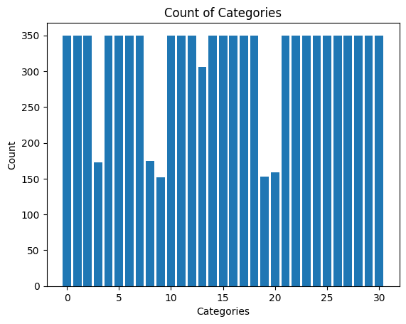

```python
# Get unique categories and their counts
category_id, counts = np.unique(y, return_counts=True)

# Create bar plot
plt.bar(category_id, counts)

# Add labels and title
plt.xlabel('Categories')
plt.ylabel('Count')
plt.title('Count of Categories')

# Show plot
plt.show()
```

The distribution of the classes shows that the dataset is almost evenly distributed except 5 classes where the number of data entries are around 175. Wheras almost all the other classes have 350 entries each.

### **SAMPLE IMAGE DISPLAY:**

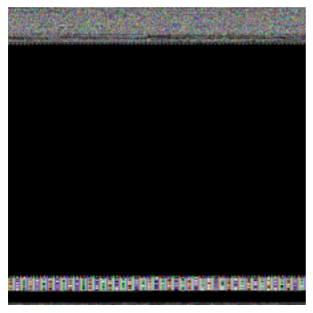

```python
plt.imshow(X[15, :, :, :])  # Display image at index 15
plt.axis('off')
plt.show()
```

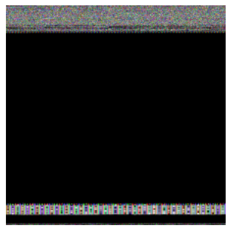

```python
plt.imshow(X[17, :, :, :])  # Display image at index 17
plt.axis('off')
plt.show()
```

Since there are training images that look almost the same and to diversify the model even more, we will augment variations of images and train on them.

### **DATA AUGMENTATION:**

To increase the model robustness and generalization, we augment data. Since byplot images are representation of the malware, augmenting them should not change the underlying representation. Therefore, techniques that do not change them are applied to the existing byplot images to generate new variations of those images.

```python
# Data augmentation
datagen = ImageDataGenerator(
    rotation_range=20,
    width_shift_range=0.2,
    height_shift_range=0.2,
    shear_range=0.2,
    zoom_range=0.2,
    horizontal_flip=True,
    vertical_flip=True,
    fill_mode='nearest'
)
datagen.fit(X)

desired_batches = 6
augmented_data = []

# Generate the specified number of batches
for _ in range(desired_batches):
    batch = next(datagen.flow(X, y, batch_size=64))
    augmented_data.append(batch)

# Concatenate all batches into a single array
X_augmented = np.concatenate([batch[0] for batch in augmented_data])
y_augmented = np.concatenate([batch[1] for batch in augmented_data])
```

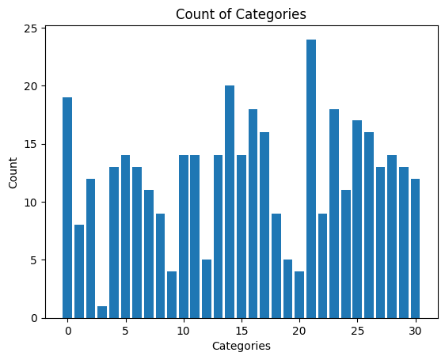

```python
# Get unique categories and their counts
category_id, counts = np.unique(y_augmented, return_counts=True)

# Create bar plot
plt.bar(category_id, counts)

# Add labels and title
plt.xlabel('Categories')
plt.ylabel('Count')
plt.title('Count of Categories')

# Show plot
plt.show()
```

The graph shows the distribution of malware files in the augmented data.

```python
X = np.concatenate((X, X_augmented), axis=0)
y = np.concatenate((y, y_augmented), axis=0)
```

### **TRAIN TEST SPLIT:**

Splitting 80% of the data into training set and 20% of the data into testing set. We are not splitting the existing training data into validation set here because a dedicated directory exists for validation sets.

```python
X_train, X_test, y_train, y_test = train_test_split(X, y, test_size=0.2, random_state=42)
```

```python
print(X_train.shape, y_train.shape, X_test.shape, y_test.shape)
```

```
(8201, 224, 224, 3) (8201,) (2051, 224, 224, 3) (2051,)
```

After splitting, there are 8201 images in the training set and 2051 images in the testing set. The values (224, 224, 3) are the dimensions of the images that are to be used for our model. Where 224 and 224 represents the height and width of the image and 3 represents the colour channels present.

### **LOADING VALIDATION SET:**

```python
# Set directory to validation set
data_path = 'data/malware_dataset/val/'

# Initialize the validation arrays
X_val = []
y_val = []

# List the categories of malwares in validation directory
malware_categories = os.listdir(data_path)

for category in tqdm(malware_categories):
    # Obtain the list of image files in each category
    files = os.listdir(os.path.join(data_path, category))

    for file in files:
        # Convert and resize
        image = cv2.imread(os.path.join(data_path, category, file))
        image = cv2.cvtColor(image, cv2.COLOR_BGR2RGB)  # Convert to RGB if necessary
        image = cv2.resize(image, (224, 224))  # Resize the image

        X_val.append(image)
        y_val.append(category)
```

```python
# Convert the list to numpy array
X_val = np.array(X_val)
y_val = np.array(y_val)

y_val = label_encoder.fit_transform(y_val)
```

### **FEATURE EXTRACTION:**

### **VGG16**

*Why VGG16?*

VGG16 is a convolutional neural network (CNN) architecture known for its simplicity and **effectiveness in image classification** tasks. In the context of malware detection, byplot images derived from PE files can be treated as images, and VGG16 can effectively extract hierarchical features from these images.

VGG16 has been **pre-trained on large-scale image datasets like ImageNet**, which helps in capturing generic features such as edges, textures, and shapes. Fine-tuning VGG16 on your byplot images allows you to leverage these pre-learned features and adapt them to your specific malware detection task, even if your dataset is relatively small.

```python
from tensorflow.keras.applications import VGG16
```

```python
# Function to extract VGG features
def extract_vgg_features(images):
    # Load pre-trained VGG16 model without top layers
    base_model = VGG16(weights='imagenet', include_top=False)

    # Create a new model with the output of the second last layer
    model = Model(inputs=base_model.input, outputs=base_model.get_layer('block5_pool').output)

    # Extract features
    features = model.predict(images)

    return features
```

```python
# Extract features from X_train and X_test
vgg_features_train = extract_vgg_features(X_train)
vgg_features_test = extract_vgg_features(X_test)

# Flatten VGG features
vgg_features_train_flat = vgg_features_train.reshape(vgg_features_train.shape[0], -1)
vgg_features_test_flat = vgg_features_test.reshape(vgg_features_test.shape[0], -1)

# Train a logistic regression classifier on flattened VGG features
classifier_vgg = LogisticRegression()
classifier_vgg.fit(vgg_features_train_flat, y_train)

# Predict labels for the test set
y_pred_vgg = classifier_vgg.predict(vgg_features_test_flat)

# Evaluate performance
print("VGG Features Classification Report:")
print(classification_report(y_test, y_pred_vgg))
```

```
257/257 ━━━━━━━━━━━━━━━━━━━━ 566s 2s/step
65/65 ━━━━━━━━━━━━━━━━━━━━ 116s 2s/step
VGG Features Classification Report:
              precision    recall  f1-score   support

           0       1.00      1.00      1.00        81
           1       0.91      0.89      0.90        75
           2       0.99      0.95      0.97        76
           3       1.00      1.00      1.00        41
           4       0.94      0.92      0.93        65
           5       0.90      0.91      0.91        79
           6       0.86      0.89      0.87        70
           7       0.92      0.96      0.94        73
           8       0.97      0.94      0.95        32
           9       1.00      1.00      1.00        33
```

[output cut: 25 more lines]

### **RESNET50:**

*Why ResNet50?*

ResNet50 is a more advanced CNN architecture that introduced **residual connections**, enabling the training of much deeper networks without suffering from the vanishing gradient problem. This architecture is particularly useful when dealing with very deep networks, as in the case of VGG16, but with reduced complexity.

ResNet50's residual connections allow for smoother gradient flow during training, facilitating the optimization of deeper networks. In the context of feature extraction from byplot images, this can potentially capture more intricate and nuanced patterns related to malware characteristics.

```python
# Load pre-trained ResNet50 model (without top classification layer)
base_model = ResNet50(weights='imagenet', include_top=False)

# Define a new model that extracts features from the output of the last convolutional layer
model = Model(inputs=base_model.input, outputs=base_model.output)

resnet_features_train = model.predict(X_train)
resnet_features_test = model.predict(X_test)

# Flatten ResNet features
resnet_features_train_flat = vgg_features_train.reshape(resnet_features_train.shape[0], -1)
resnet_features_test_flat = vgg_features_test.reshape(resnet_features_test.shape[0], -1)

# Train classifier on LBP features
classifier_resnet = LogisticRegression()
classifier_resnet.fit(resnet_features_train_flat, y_train)

# Predict labels for the test set
y_pred_resnet = classifier_resnet.predict(resnet_features_test_flat)

# Evaluate performance
print("Classification Report:")
print(classification_report(y_test, y_pred_resnet))
```

```
257/257 ━━━━━━━━━━━━━━━━━━━━ 199s 764ms/step
65/65 ━━━━━━━━━━━━━━━━━━━━ 48s 729ms/step
```

```
Classification Report:
              precision    recall  f1-score   support

           0       1.00      1.00      1.00        81
           1       0.91      0.89      0.90        75
           2       0.99      0.95      0.97        76
           3       1.00      1.00      1.00        41
           4       0.94      0.92      0.93        65
           5       0.90      0.91      0.91        79
           6       0.86      0.89      0.87        70
           7       0.92      0.96      0.94        73
           8       0.97      0.94      0.95        32
           9       1.00      1.00      1.00        33
          10       0.99      0.97      0.98        89
          11       0.94      0.97      0.95        74
```

[output cut: 23 more lines]

### **LBP:**

*Why LBP?*

LBP is a texture descriptor that characterizes the local patterns in an image. In the context of malware detection, LBP can capture important **texture-based features** in the byplot images, which may represent distinctive characteristics of malware.

Byplot images may contain texture variations that are indicative of certain malware behaviors or signatures. LBP efficiently captures such texture information by analyzing the local pixel intensity patterns, making it suitable for extracting relevant features from the images.

Compared to deep neural networks like VGG16 and ResNet50, LBP is computationally lightweight and has lower memory requirements. This makes it a practical choice, especially in scenarios where computational resources are limited or where real-time processing is required.

```python
from skimage import color

from skimage.feature import local_binary_pattern
import numpy as np

# Function to extract LBP features
def extract_lbp_features(images):
    lbp_features = []
    for image in images:
        # Convert image to grayscale
        gray_image = color.rgb2gray(image)

        # Extract LBP features
        lbp = local_binary_pattern(gray_image, P=8, R=1, method='uniform')
        hist, _ = np.histogram(lbp.ravel(), bins=np.arange(0, 10), range=(0, 9))
        hist = hist.astype("float")
        hist /= (hist.sum() + 1e-7)

        # Append LBP features
        lbp_features.append(hist)

    return np.array(lbp_features)
```

```python
# Extract LBP features from training and testing images
lbp_features_train = extract_lbp_features(X_train)
lbp_features_test = extract_lbp_features(X_test)

# Train classifier on LBP features
classifier_lbp = LogisticRegression()
classifier_lbp.fit(lbp_features_train, y_train)

# Predict labels for the test set
y_pred_lbp = classifier_lbp.predict(lbp_features_test)

# Evaluate performance
print("LBP Classification Report:")
print(classification_report(y_test, y_pred_lbp))
```

[output not shown]

[output cut: 23 more lines]

The LBP Features seem to struggle with certain malware types, resulting in poor classification performance overall.

### **MODEL TRAINING:**

*Why use a GBM (Gradient Boosting Machine)?*

GBMs build predictive models in a stage-wise manner by **combining the predictions of multiple weak learners**, typically decision trees. The key idea behind gradient boosting is to optimize a loss function by **iteratively fitting weak learners** to the negative gradient of the loss function. In each stage of training, the new weak learner is trained to minimize the residual errors (the negative gradient) made by the existing ensemble.

We are using LGBMClassifier developed by Microsoft.

```python
# Training the LightGBM model with extracted features
lgb_model = lgb.LGBMClassifier(verbose=0)
lgb_model.fit(vgg_features_train_flat, y_train)
```

[output not shown]

[output cut: 1381 more lines]

[output not shown]

```
LGBMClassifier(verbose=0)
```

```python
X_val_features = extract_vgg_features(X_val)
X_val_features = X_val_features.reshape(X_val_features.shape[0], -1)
```

```
122/122 ━━━━━━━━━━━━━━━━━━━━ 212s 2s/step
```

```python
y_val_pred = lgb_model.predict(X_val_features)
```

### **MODEL VALIDATION:**

With the LGBM Classifier fitted with the extracted features we will validate the model using the validation dataset. We will measure model efficiency using the metrics accuracy, precision, recall, f1-score. We will observe the confusion matrix to see how well the model has predicted correctly.

```python
from sklearn.metrics import accuracy_score, confusion_matrix, precision_score, recall_score, f1_score
```

```python
# Calculate accuracy
accuracy = accuracy_score(y_val, y_val_pred)
print("Accuracy:", accuracy)
```

```
Accuracy: 0.9551430781129157
```

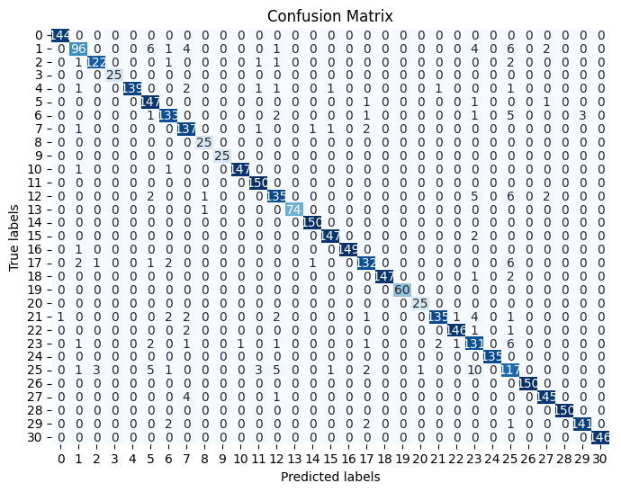

```python
import seaborn as sns

# Calculate confusion matrix
conf_matrix = confusion_matrix(y_val, y_val_pred)

# Plot confusion matrix
plt.figure(figsize=(8, 6))
sns.heatmap(conf_matrix, annot=True, fmt='d', cmap='Blues', cbar=False)
plt.xlabel('Predicted labels')
plt.ylabel('True labels')
plt.title('Confusion Matrix')
plt.show()
```

```python
# Calculate precision
precision = precision_score(y_val, y_val_pred, average='macro')
print("Precision:", precision)
```

```
Precision: 0.9592628126984982
```

```python
# Calculate recall
recall = recall_score(y_val, y_val_pred, average='macro')
print("Recall:", recall)
```

```
Recall: 0.9604331636636619
```

```python
# Calculate F1-score
f1 = f1_score(y_val, y_val_pred, average='macro')
print("F1-score:", f1)
```

```
F1-score: 0.9594211712145454
```

### **MODEL EVALUATION:**

```python
y_test_pred = lgb_model.predict(vgg_features_test_flat)
```

```python
test_class_report = classification_report(y_test, y_test_pred)
print("Classification Report on Test set:")
print(test_class_report)
```

```
Classification Report on Test set:
              precision    recall  f1-score   support

           0       0.96      0.99      0.98        81
           1       0.90      0.92      0.91        75
           2       0.95      0.95      0.95        76
           3       1.00      1.00      1.00        41
           4       0.98      0.94      0.96        65
           5       0.88      0.90      0.89        79
           6       0.87      0.84      0.86        70
           7       0.95      0.95      0.95        73
           8       0.94      0.94      0.94        32
           9       0.97      0.97      0.97        33
          10       0.96      0.96      0.96        89
          11       0.91      0.96      0.93        74
```

[output cut: 23 more lines]

The model shows particularly high performance for classes 0, 3, 14, 15, 16, 18, 19, and 20, with precision, recall, and F1-score close to or at 1.0. Some classes, such as 17 and 21, have slightly lower recall values, indicating that the model may have more difficulty correctly identifying instances of those classes. The metrics suggest that the model performs well on the test set, with high accuracy and balanced performance across various malware types.

### **DEPLOYMENT:**

```python
import tkinter as tk
from tkinter import filedialog
from tkinter import messagebox

# Function to perform feature extraction and prediction
def extract_and_predict(file_path):
    image = cv2.imread(file_path)
    image = cv2.cvtColor(image, cv2.COLOR_BGR2RGB)  # Convert to RGB if necessary
    image = cv2.resize(image, (224, 224))  # Resize the image
    in_feature = extract_vgg_features(np.array([image]))
    in_feature_flat = in_feature.reshape(in_feature.shape[0], -1)  # Reshape with the extracted features
    prediction = lgb_model.predict(in_feature_flat)
    return prediction

# Function to handle file selection
def select_file():
    file_path = filedialog.askopenfilename(initialdir=os.path.join(os.getcwd(), 'data', 'malware_dataset', 'val'), title="Select File")
    if file_path:
        # Perform feature extraction and prediction
        prediction = extract_and_predict(file_path)
        # Get the malware class
        malware_class = label_encoder.inverse_transform([prediction])
        # Display results
        messagebox.showinfo("Malware Type: ", f"{malware_class[0]}")

# Main Tkinter window
root = tk.Tk()
root.title("Malware Detection")

# Create UI elements
label = tk.Label(root, text="Select a file from malware directory:")
label.pack(pady=10)

browse_button = tk.Button(root, text="Browse", command=select_file)
browse_button.pack(pady=5)

# Run the Tkinter event loop
root.mainloop()
```

```
1/1 ━━━━━━━━━━━━━━━━━━━━ 0s 237ms/step
```